# The Question:

### How do we do that?

- Give each seller several months of honeymoon (probation)
- Evaluate their performance by the end of their honeymoons
- Cut off consistently **bad-performing sellers**:

  -having profit<0

  **or**

  -with average score < certain threshold (e.g. 1.5)

How long is the honeymoon?

- 3 months, 6 months, 8 months, 10 months, 12 months, 14 months, or 18 months?

What score is considered "bad"?

- average score <1.5, < 2.5, < 3.5 or < 4?

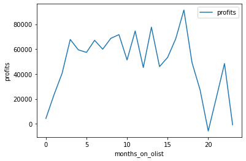

```python
seller[['months_on_olist','profits']].groupby('months_on_olist').sum().plot()
plt.ylabel('profits');
```

Reasonable choices for honeymoon: 3 months, 6 months, 8 months, 10 months, 12 months, 14 months,

What score is considered "bad"?

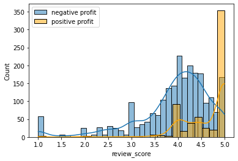

```python
# Get the total number of orders from
sns.histplot(seller_neg['review_score'],kde=1,label='negative profit')
sns.histplot(seller_pos['review_score'],kde=True,label='positive profit',color='orange')
plt.legend();
```

```python
s1=seller_neg[['review_score']].describe()
s2=seller_pos[['review_score']].describe()
s=pd.concat([s1,s2],axis=1)
s.columns=['score_of_neg_sellers','score_of_pos_sellers']
s
```

|  | score_of_neg_sellers | score_of_pos_sellers |
| --- | --- | --- |
| count | 2334.000 | 633.000 |
| mean | 3.926 | 4.623 |
| std | 0.821 | 0.563 |
| min | 1.000 | 1.000 |
| 25% | 3.667 | 4.301 |
| 50% | 4.086 | 5.000 |
| 75% | 4.447 | 5.000 |
| max | 5.000 | 5.000 |

Maybe those with an average score $<$ 2.5, $<$ 3.5 or $<$ 4 should be filtered?

```python
Seller().get_improvement_data(months,scores,'profits',Turn_on_percentage=True)
```

| length_of_honeymoon index | 3 | 6 | 8 | 10 | 12 | 14 | 18 |
| --- | --- | --- | --- | --- | --- | --- | --- |
| score <=1.5 | 24.78% | 23.43% | 21.67% | 20.73% | 18.06% | 14.56% | 11.78% |
| score <=2.5 | 23.77% | 22.64% | 21.20% | 20.38% | 17.71% | 14.22% | 11.78% |
| score <=3.5 | 17.76% | 17.55% | 17.48% | 17.46% | 15.23% | 12.26% | 11.16% |
| score <=4 | -1.47% | 0.86% | 2.71% | 5.42% | 5.35% | 4.98% | 8.14% |

```python
Seller().get_improvement_data(months,scores,'volumn_reduced',Turn_on_percentage=True)
```

| length_of_honeymoon index | 3 | 6 | 8 | 10 | 12 | 14 | 18 |
| --- | --- | --- | --- | --- | --- | --- | --- |
| score <=1.5 | -34.29% | -32.76% | -31.04% | -29.58% | -26.40% | -21.92% | -16.45% |
| score <=2.5 | -34.38% | -32.81% | -31.06% | -29.59% | -26.41% | -21.93% | -16.45% |
| score <=3.5 | -35.51% | -33.72% | -31.65% | -30.00% | -26.74% | -22.17% | -16.50% |
| score <=4 | -44.01% | -41.25% | -38.63% | -36.09% | -31.66% | -25.97% | -18.06% |

```python
Seller().get_improvement_data(months,scores,'cost_of_reviews',Turn_on_percentage=True)
```

| length_of_honeymoon index | 3 | 6 | 8 | 10 | 12 | 14 | 18 |
| --- | --- | --- | --- | --- | --- | --- | --- |
| score <=1.5 | -46.39% | -43.65% | -40.76% | -38.46% | -34.45% | -28.68% | -21.63% |
| score <=2.5 | -46.83% | -43.86% | -40.86% | -38.52% | -34.51% | -28.74% | -21.63% |
| score <=3.5 | -49.87% | -46.30% | -42.42% | -39.60% | -35.36% | -29.36% | -21.76% |
| score <=4 | -62.69% | -57.53% | -52.74% | -48.60% | -42.60% | -34.91% | -24.15% |

```python
Seller().get_improvement_data(months,scores,'IT_cost',Turn_on_percentage=True)
```

| length_of_honeymoon index | 3 | 6 | 8 | 10 | 12 | 14 | 18 |
| --- | --- | --- | --- | --- | --- | --- | --- |
| score <=1.5 | -17.83% | -15.99% | -14.55% | -13.31% | -11.40% | -9.18% | -6.39% |
| score <=2.5 | -18.23% | -16.17% | -14.63% | -13.35% | -11.45% | -9.22% | -6.39% |
| score <=3.5 | -21.45% | -18.53% | -16.07% | -14.30% | -12.19% | -9.75% | -6.52% |
| score <=4 | -34.57% | -29.14% | -25.26% | -21.81% | -18.06% | -14.08% | -8.34% |

### Conclusion

Based on the information we have so far, we recommend a honeymoon of length from 3 or 6 months, a cut-off score of 1.5 or 2.5. However, we didn't include IT_cost into the profit, change in IT_cost should also be considered.